# 03 Throubleshooting - Sera without Homologous Antigens

Sina Tureli (st757@cam.ac.uk)

2025-06-18

```r
rm(list = ls()) # clear environment at the beginning of each session
setwd(here::here("code/")) # set correct working directory
knitr::opts_chunk$set(echo = TRUE,
                      fig.width=4, fig.height=4,
                      fig.align = "center")
```

This markdown contains the exercise code to teach how and when the arguments minimum_column_basis and fixed_column_bases are useful for optimizing maps. For this exercise it is useful to know the following functions from Racmacs package: make.acmap, procrustesMap, agFill, srOutline, realignMap, colBases, srNames, tableDistances, titerTable. If you don’t know any of the functions type for instance ?realignMap to read the documentation.

### Load the required packages

```r
library(Racmacs)
```

### Load the titer data

We will be working with artificial titer data. The “ground truth” titer table is a table with thirty-four antigens and sixteen sera. Of the thirty-four antigens, thirty belong in cluster one and four belong in cluster two. Of the sixteen sera, fifteen belong in cluster one and one belongs in cluster two. Lets load the titer table, and make the ground truth map out of it (full_map).

```r
full_titerdata <- read.csv("../data/titerdata/03_colbases_fulltable.csv", row.names = "X")
full_map <- make.acmap(full_titerdata,
                       ag_names = rownames(full_titerdata),
                       sr_names = colnames(full_titerdata),
                       number_of_dimensions = 2,
                       number_of_optimizations = 500)
```

```
## a
```

```
## Took 0.63 secs
```

Exercise 1: Color the map so that first 30 antigens and first 15 sera are red, the following four antigens and the last serum is blue. Use fill coloring for antigens and outline coloring for sera. Then view the map.

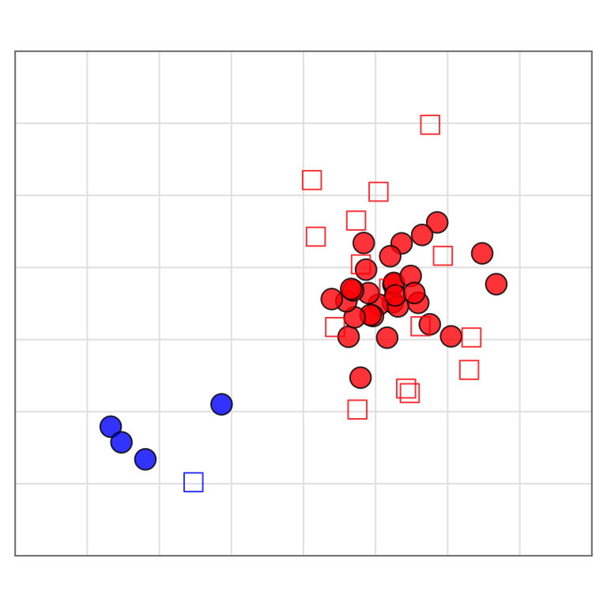

```r
agfills = append(rep("red",30), rep("blue",4))
sroutlines = append(rep("red",15), c("blue"))
agFill(full_map) <- agfills
srOutline(full_map) <- sroutlines
plot(full_map, options=list(xlim=c(-5,5), ylim=c(-5,5)))
```

For your convenience sera are named according to which antigen they are homologous to. In particular cluster two’s serum is homologous to C2_Ag3.

We can imagine that cluster 1 is the currently circulating cluster and cluster 2 is a new cluster that is just emerging and we only have partial data for. Therefore one may encounter the following scenario:

Lab 1 has all the antigens from cluster1 and antigens C2_Ag0 to C2_Ag2 but only has sera from cluster 1 and has titrated these against each other.

Lab 2 says that it was able to get a serum that it thinks should belong to cluster 2, but it only has antigens from cluster 1 and has titrated these against each other.

Combining these two, we have a titer table where the “mystery serum” (C2_Ag3_Hom_sera) has only been titrated against cluster 1 antigens and we do not have the myster serum’s homologous antigen (C2_Ag3) in the map. Lets load this table make a map from this:

```r
partial_titerdata <- read.csv("../data/titerdata/03_colbases_partialtable.csv", row.names = "X")
partial_map <- make.acmap(partial_titerdata,
                          ag_names = rownames(partial_titerdata),
                          sr_names = colnames(partial_titerdata),
                          number_of_dimensions = 2,
                          number_of_optimizations = 1000)
```

```
## a
```

```
## Took 1.39 secs
```

Exercise 2: Apply the style and orientation of the full_map to partial_map and then view the map.

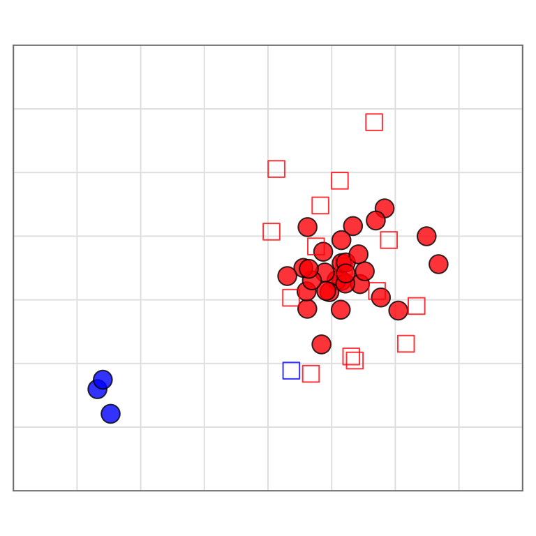

```r
partial_map <- applyPlotspec(partial_map, full_map)
partial_map <- realignMap(partial_map, full_map)
plot(partial_map, options=list(xlim=c(-5,5), ylim=c(-5,5)))
```

Well that is disappointing! Using the partial titer table, the new antigens (blue circles) still form a new cluster but the new serum (blue square), despite having very low titers to cluster 1 antigens, is very close to cluster 1. What is going on? Well remember that the titers are converted to antigen-serum distances via the following formula (Lecture 01):

$$D_{i,s} = max(log_2(titer_{s}/10)) -
log_2(titer_{i,s}/10)$$

Exercise 3: Look at the titers and table distances of the blue serum and explain why it is placed close to the red cluster.

```r
print(titerTable(partial_map)[,"C2_Ag3_Hom_Sr"])
```

```
##  C1_Ag0  C1_Ag1  C1_Ag2  C1_Ag3  C1_Ag4  C1_Ag5  C1_Ag6  C1_Ag7  C1_Ag8  C1_Ag9
##    "40"    "40"   "160"   "160"    "80"    "80"    "40"   "160"   "160"    "80"
## C1_Ag10 C1_Ag11 C1_Ag12 C1_Ag13 C1_Ag14 C1_Ag15 C1_Ag16 C1_Ag17 C1_Ag18 C1_Ag19
##   "160"   "160"    "40"    "80"    "40"   "160"    "80"    "80"    "80"    "40"
## C1_Ag20 C1_Ag21 C1_Ag22 C1_Ag23 C1_Ag24 C1_Ag25 C1_Ag26 C1_Ag27 C1_Ag28 C1_Ag29
##   "320"    "40"    "80"   "160"    "80"    "80"    "80"    "80"   "320"    "80"
##  C2_Ag0  C2_Ag1  C2_Ag2
##     "*"     "*"     "*"
```

```r
print(tableDistances(partial_map)[,16])
```

```
##  [1] "3" "3" "1" "1" "2" "2" "3" "1" "1" "2" "1" "1" "3" "2" "3" "1" "2" "2" "2"
## [20] "3" "0" "3" "2" "1" "2" "2" "2" "2" "0" "2" "*" "*" "*"
```

Note that because this serum has not been titrated against the blue cluster, its maximum titer (320) occurs against two antigens from the red cluster (C1_Ag20 and C1_Ag28). Therefore the table distance against these antigens are zero and that is what the optimization tries to achieve as well as a lot of low distances like 1 against other antigens from the red cluster. Had this serum been titrated against its homologous antigen as well and its titer was something like 1280, a titer of 320 would instead be a distance of 2 instead of 0. So maybe the formula can be changed somewhat to reflect this fact. Note that the intention of the formula above is to produce something to the effect of

$$D_{i,s} = hom_s -
log_2(titer_{i,s}/10)$$

where the first term on the RHS is the homologous titer of serum s. We do not use this formula but replace it with maximum for two reasons:

1- It is not uncommon to have non-homologous titers which are somewhat higher than the homologous titer (high reactivity antigens for instance), and in order to avoid negative table distances, we use maximum instead.

2- It is not uncommon to have a serum not titrated against the homologous antigen but it might still be titrated against another antigen which is antigenically similar to its homologous antigen which is expected to have similarly high titers. Therefore maximum titer still captures a value similar to the homologous titer.

The maximum term

$$max(log_2(titer_{s}/10))$$

is called the column basis for the serum s. This formula works fine as long as we have antigens which have reactivity similar to the homologous antigen of serum s. If not then even the maximum might be quite low. For instance if a serum which has not been titrated against its homologous or similar antigens has all <10 for its titers, its table distances to each of these antigens will be zero but in reality one can expect this serum to be quite further away from these antigens because very low titers might indicate antigenic differences. If we expect that the homologous antigen titer should be something around 1280, then we can replace the formula above with:

$$D_{i,s} = max(1280,
max(log_2(titer_{s}/10))) - log_2(titer_{i,s}/10)$$

This is what the minimum_column_basis parameter in make.map does (but you can replace 1280 with any number you want). In order to determine what is a reasonable value for homologous antigen titers is, lets look at what they look like for the red cluster.

Exercise 4: Extract the column basis for the red cluster and plot them as a scatter plot and plot the mean using a line

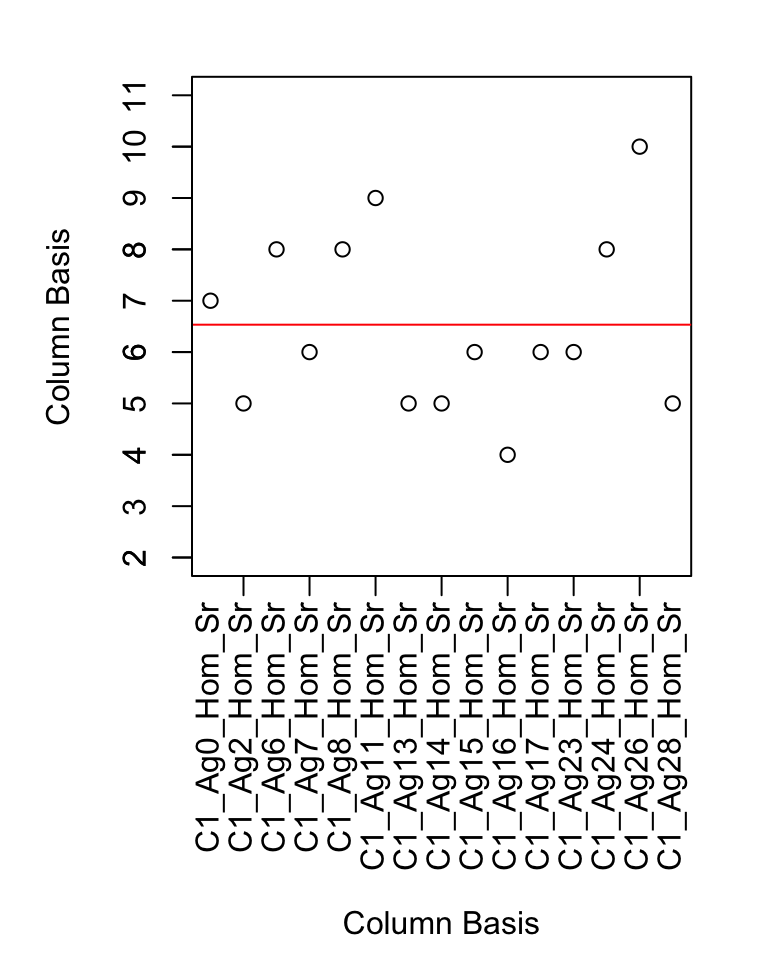

```r
cb <- colBases(partial_map)[1:15]
sera = srNames(partial_map)[1:15]

#set figure margins
par(mar=c(10, 5, 2, 2))

#plot column bases and mean
plot(cb, xlab="", ylab="Column Basis", xaxt="n", ylim=c(2, 11))
abline(h=mean(cb), col="red")

#format axes
axis(1, labels=FALSE)
axis(2, at=2:11)
text(x=1:15, y=par("usr")[3]-0.5, labels=sera, srt=90, adj=1, xpd=TRUE, xaxt="n")
mtext("Column Basis", side=1, line=8.5, cex=1)
```

So the column basis seems to be centered around 6-7 in log scale or 640-1280 in linear scale (note that conversion to log scale is done via log2(titer/10)). So we can try setting the minimum column basis at 6 or 7 (the minimum column basis input must be in linear domain and in string format). Can you guess what is going to happen to distances of cluster 1 when we do that (especially for those whose maximum titers are less than 1280). Compute the map with minimum_column_basis of 1280, apply the style and orientation of full_map then do a procrustes of this new map against the full_map.

```r
mincol_map <- make.acmap(partial_titerdata,
                         ag_names = rownames(partial_titerdata),
                         sr_names = colnames(partial_titerdata),
                         number_of_dimensions = 2,
                         number_of_optimizations = 2000,
                         minimum_column_basis = "1280")
```

```
## a
```

```
## Took 2.8 secs
```

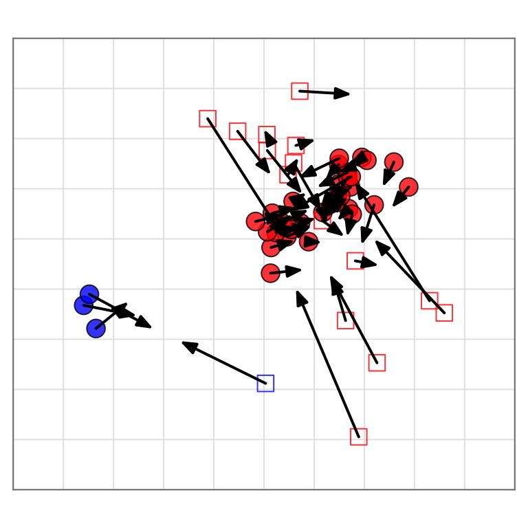

```r
mincol_map <- applyPlotspec(mincol_map, full_map)
mincol_map <- realignMap(mincol_map, full_map)
plot(procrustesMap(mincol_map, full_map), options=list(xlim=c(-5,5), ylim=c(-5,5)))
```

```r
print(as.integer(tableDistances(mincol_map)[,10]) - as.integer(tableDistances(partial_map)[,10]))
```

```
##  [1] 3 3 3 3 3 3 3 3 3 3 3 3 3 3 3 3 3 3 3 3 3 3 3 3 3 3 3 3 3 3 3 3 3
```

We can try decreasing the column basis so that the red cluster is distorted less but then the blue serum will move closer to the red cluster again. We leave this as an extra exercise for the interested reader.

So it seems these the two goals of keeping the red cluster intact but getting the true distance of blue serum from the center of the red cluster are contradictory to each other. Is there a more clever way of doing this? Could we for instance just set the minimum_column_basis for a chosen subset of sera and leave the others as they are (that is whatever the maximum value is). The argument fixed_column_bases allows us to do just that. This should be a vector of values with length equal to number of sera and sets the minimum column basis for each serum individually (unlike minimum_column_basis, it should be supplied in log values). So if we were to supply as input a vector which is equal to maximum titer for all the red sera and 7 for the blue serum, then we can achieve what we want. Carry out this in the next exercise and view the map as before:

```r
cb <- apply(X=logtiterTable(partial_map), FUN=max, MARGIN=2,
            na.rm=TRUE)
# you also use the colBases function on partial_map. Think about why
# na.rm=TRUE is necessary here.

# set the column basis for the blue serum to 7, in the table with missing
# data it is 5.
cb[[16]] = 7

fixedcol_map <- make.acmap(partial_titerdata,
                           ag_names = rownames(partial_titerdata),
                           sr_names = colnames(partial_titerdata),
                           number_of_dimensions = 2,
                           number_of_optimizations = 2000,
                           fixed_column_bases = cb)
```

```
## a
```

```
## Took 2.96 secs
```

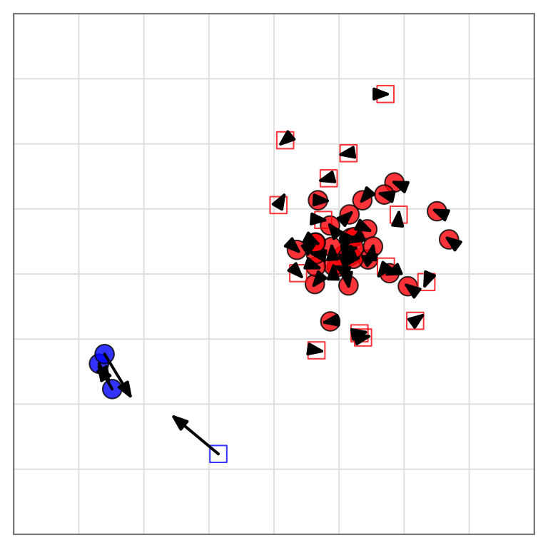

```r
fixedcol_map <- applyPlotspec(fixedcol_map, full_map)
fixedcol_map <- realignMap(fixedcol_map, full_map)
plot(procrustesMap(fixedcol_map, full_map),
     options=list(xlim=c(-5,5), ylim=c(-5,5)))
```

Now the map looks much more reasonable. Note that we supplied a minimum column basis of 7 for the blue serum guided by what we have seen from other sera’s column bases in exercise 4. The “real” column basis of this serum is indeed 7 (you can see this from the full_map), although it could be quite lower or higher than the mean we estimated. In reality we won’t be privy to this information and will likely have to try different minimum column basis values for this serum and will have to decide on a value based on parsimony with other sources of information. The exercise here presents you the best case scenario where you can guess the missing column bases correctly and you are right about your judgment about the other sera that they have the correct column basis.

In summary, the main justification for using the minimum/fixed column basis approach would be that the titers of the blue serum (from the partial table) are generally quite low and that it is likely not titrated against an antigen which is similar to its homologous antigen. There is still the possibility that this serum was actually from the red cluster but it is a low reactivity serum and thus has generally low titers, even against its homologous antigen. Therefore, where as this approach can resolve issues arising from not titrating against homologous antigens, its usage should be determined by carefully weighing every other piece of information you have about these antigens and sera and the reason for the choice should be clearly documented. Ideally this approach should be more like a first pass analysis of the possible ranges of antigenic relationships between the sera and antigens in the map. In this case a scientist could argue that the situation is unclear: if the new serum is a low reactivity serum it could as well be from the red cluster, but if it is not then it most likely comes from a distinct cluster. This conclusion then should be revisited in a future time point with newly accumulated experimental data and scientific knowledge.